# A3

Kevin O’Brien

5 December 2018

a3.gen.default Stochastic Data Generators #### Description The stochastic data generators generate stochastic noise with (if specified correctly) the same properties as the observed data. By replicating the stochastic properties of the original data, we are able to obtain the exact calculation of p values. #### Usage

```
a3.gen.default(x, n.reps)
```

#### Arguments

x the original (observed) data series. n.reps the number of stochastic repetitions to generate.

#### Details

Generally these will not be called directly but will instead be passed to the data.generating.fn argument of a3.base.

Value A list of of length n.reps of vectors of stochastic noise. There are a number of different methods of generating noise: a3.gen.default The default data generator. Uses a3.gen.bootstrap. a3.gen.resample Reorders the original data series. a3.gen.bootstrap Resamples the original data series with replacement. a3.gen.normal Calculates the mean and standard deviation of the original series and generates a new series with that distribution. a3.gen.autocor Assumesa first order autocorrelation of the original series and generates a new series with the same properties.

#### Examples

```r
# Calculate the A3 results assuming an auto-correlated set of observations.
# In usage p.acc should be <=0.01 in order to obtain more accurate p values.
a3.lm(rating ~ ., attitude, p.acc = 0.1,
data.generating.fn = replicate(ncol(attitude), a3.gen.autocor))
```

```
##              Average Slope   CV R^2 p value
## -Full Model-                 56.7 %   < 0.1
## (Intercept)        10.7871 -  5.4 %     0.5
## complaints          0.6132 + 22.0 %   < 0.1
## privileges         -0.0731 -  2.7 %     0.6
## learning            0.3203 +  3.6 %   < 0.1
## raises              0.0817 -  2.6 %     0.5
## critical            0.0384 -  1.9 %     0.5
## advance            -0.2171 +  1.2 %     0.2
```

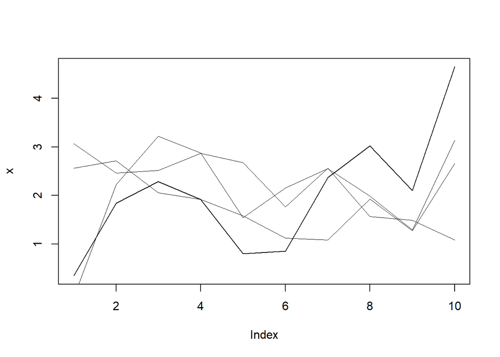

```r
## A general illustration:
# Take x as a sample set of observations for a feature
x <- c(0.349, 1.845, 2.287, 1.921, 0.803, 0.855, 2.368, 3.023, 2.102, 4.648)
# Generate three stochastic data series with the same autocorrelation properties as x
rand.x <- a3.gen.autocor(x, 3)
plot(x, type="l")
for(i in 1:3) lines(rand.x[[i]], lwd = 0.2)
```